# Project

2022-11-17

# Introduction

For this project, we retrieved data from [FBref](https://fbref.com/en/), our data contain Football Clubs and Players’ performance stat in the Top 5 European Leagues last season and this season. To organize our study more smoothly, we also find several data such as FIFA net income and player transfer history. In this project, we dived into Premier League and studied why Liverpool’s performance has been worse this season. At the end, we also implemented K-means clustering, try to identify different roles within each position.

## EDA

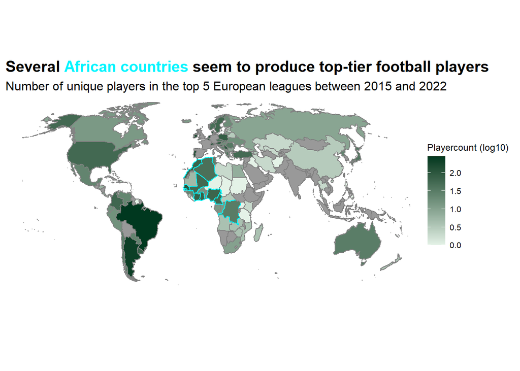

```r
# Create map of the world
map <- ne_countries(scale = "medium", returnclass = "sf") %>%
  dplyr::select(name, iso_a3, geometry) %>%
  filter(!name %in% c("Greenland", "Antarctica"))

# Create map filled with count of players per nation
players_by_country <- map %>%
  left_join(nations_n, by = "name") %>% # join map data with calculation of player count
  # Create plot
  ggplot() +
    geom_sf(mapping = aes(geometry = geometry, fill = log10(count), colour = africa)) + # colour to highlight African countries of interest
    coord_sf(crs = "+proj=robin") +  # change coords for more accurate representation of map
    scale_color_manual(values = c("#838383", "#04f5ff"), guide = "none") + # define manual colours for highlight African countries of interest
    scale_fill_gradient(
    low = "#E4F2E7",
    high = '#00381F',
    na.value = "grey60",) + # change gradient fill colours
    theme(panel.background = element_blank(), # remove background
          axis.ticks = element_blank(), # remove axis ticks
          legend.title = element_text(size = 9), # adjust legend title size
          legend.text = element_text(size = 8), # adjust legend text size
          axis.text = element_blank(), # remove axis labels
          plot.title.position = "plot", # left align title
          plot.title = element_textbox_simple(size=15)) + # change title size
  # Change labels
  labs(title = "<b>Several<span style='color:#04f5ff'> African countries</span> seem to produce top-tier football players</span></b><br>
         <span style = 'font-size:12pt'>Number of unique players in the top 5 European leagues between 2015 and 2022",
         fill = "Playercount (log10)",
         x = "",
         y = "") +
  xlim(-13000000,15000000) # change span of x axis

# View map
players_by_country
```

[figure not shown]

```r
# Save plot
ggsave(
  plot = players_by_country,
  filename = "players_by_country.png",
  bg = "transparent"
)
# Download team spi data
team_spi <- read.csv("data/spi_global_rankings.csv", header = TRUE) %>%
  rename(name = country)

# Define countries of Europe
eur_countries <- c("Austria","Belgium","Bulgaria","Croatia","Cyprus",
                    "Czech Rep.","Denmark","Estonia","Finland","France",
                    "Germany","Greece","Hungary","Ireland","Italy","Latvia",
                    "Lithuania","Luxembourg","Malta","Netherlands","Norway", "Poland",
                    "Portugal","Romania","Slovakia","Slovenia","Spain",
                    "Sweden", "Switzerland", "United Kingdom")

# Import data on team logo pngs
team_logos <- read.csv("data/team_logos.csv")

# Find top team based on SPI per country
team_spi_top <- team_spi %>%
  group_by(name) %>% # group for summarization
  slice_max(spi, n = 1) %>% # find top team per country
  filter(name %in% eur_countries) %>% # only select european teams
  left_join(team_logos, by = "team") # join logo png data for later fill

# Get map of Europe data
eu_map <- map %>%
  filter(name %in% eur_countries)

# Join map geom data with png and SPI data
plot <- eu_map %>%
  left_join(team_spi_top, by = "name")

# Create map of Europe
actual_map <- eu_map %>%
  ggplot() +
    geom_sf(color = "black", fill = "#E4F2E7") + # Define border and fill colours
    coord_sf(crs = "+proj=robin") + # change coords to create more accurate map
    theme_minimal() + # Change theme
    theme(panel.grid = element_blank(), # remove gridlines
          panel.background = element_blank(), # remove background
          plot.title.position = "plot", # left align title
          plot.title = element_textbox_simple(size=15)) + # change title size) +
  # Adjust labels
    labs(title = "<b>Every country has its best-performing team, but there are gaps between nations </b><br>
          Logos of the currently best performing teams according to fivethirtyeight per country")

# Create loop to download and add logos to map
for (row in 1:nrow(team_logos)) {
  if(team_logos[row,2] == "") next # skip if no data is available for logo
  # Download pic and plot
  imgurl <- team_logos[row,2] # retrieve file url
  tmpfile <- tempfile(fileext = ".png") # define temporary save location
  download.file(url = imgurl, destfile = tmpfile, quiet = TRUE, mode = "wb") # download logo

  # Raster
  x <- plot[row,]
  x_rast <- rasterpic_img(x, tmpfile, crop = TRUE, mask = TRUE) # define variable for png
  actual_map <- actual_map + layer_spatial(x_rast) # add logo to map
}
# Download logos not added automatically to plot, due to faulty geom data from naturalearth
psg <- readPNG("data/logos_extra/psg.png", native = TRUE) # load image for graph
ajax <- readPNG("data/logos_extra/ajax.png", native = TRUE) # load image for graph
barcelona <- readPNG("data/logos_extra/barcelona.png", native = TRUE) # load image for graph
porto <- readPNG("data/logos_extra/porto.png", native = TRUE) # load image for graph

# Add logo of PSG
actual_map_comp <- actual_map +
    xlim(-20, 55) +
    ylim(35, 70) +
    theme(axis.text = element_blank(),
          panel.background = element_blank()) +
    inset_element(p = psg,
                 left = 0.24,
                 bottom = 0.29,
                 right = 0.4,
                 top = 0.41) +
    theme(rect  = element_rect(fill="transparent", linetype = "blank"))

# Add logo of Ajax
actual_map_comp <- actual_map_comp +
  inset_element(p = ajax,
                 left = 0.335,
                 bottom = 0.48,
                 right = 0.375,
                 top = 0.52) +
  theme(rect  = element_rect(fill="transparent", linetype = "blank"))

# Add logo of Barcelona
actual_map_comp <- actual_map_comp +
    inset_element(p = barcelona,
                 left = 0.205,
                 bottom = 0.07,
                 right = 0.285,
                 top = 0.3) +
    theme(rect  = element_rect(fill="transparent", linetype = "blank"))

# Add logo of FC Porto
actual_map_comp <- actual_map_comp +
    inset_element(p = porto,
                 left = 0.165,
                 bottom = 0.18,
                 right = 0.215,
                 top = 0.21) +
    theme(rect  = element_rect(fill="transparent", linetype = "blank"))

actual_map_comp
```

```r
# Save plot
ggsave(
  plot = actual_map_comp,
  filename = "map_best_teams.png",
  bg = "transparent"
)
# Create table of SPI values of top teams per country in order
spi_table <- team_spi_top %>%
  select(name, spi) %>%
  rename("Country" = "name", "SPI" = "spi") %>%
  arrange(desc(SPI))
```

## Transfer

```r
library(tidyverse)
library(extrafont)
library(vroom)
library(ggtext)
library(gapminder)
library(ggrepel)
library(patchwork)
library(gghighlight)
library(skimr)
library(ggridges)
library(maps)
library(reshape2)
library(rgdal)
library(lubridate)
library(ggforce)
library(tidyr)
library(dplyr)
library(countrycode)
library(ggflags)
library(png)
library(grid)
library(sf) # for geospatial visualisation
#read csv file
data_dir <- "~/Desktop/LBS/am10-group8-football-project/data/transfer"

files <- fs::dir_ls(path = data_dir, regexp = "\\.csv$", recurse = TRUE)
#recurse=TRUE will recursively look for files further down into any folders

#read them all in using vroom::vroom()
football_transfer <- vroom(files, id = "source")
# Use janitor to clean names, and add more variables
football_transfer_all <- football_transfer %>%
  janitor::clean_names()

# skimr::skim() to inspect and get a feel for the data
skim(football_transfer_all)
```

Data summary

| Name | football_transfer_all |
| --- | --- |
| Number of rows | 170349 |
| Number of columns | 13 |
| _______________________ |  |
| Column type frequency: |  |
| character | 10 |
| numeric | 3 |
| ________________________ |  |
| Group variables | None |

**Variable type: character**

| skim_variable | n_missing | complete_rate | min | max | empty | n_unique | whitespace |
| --- | --- | --- | --- | --- | --- | --- | --- |
| source | 0 | 1 | 78 | 87 | 0 | 9 | 0 |
| club_name | 0 | 1 | 4 | 48 | 0 | 408 | 0 |
| player_name | 0 | 1 | 2 | 32 | 0 | 35779 | 0 |
| position | 0 | 1 | 6 | 18 | 0 | 17 | 0 |
| club_involved_name | 0 | 1 | 3 | 29 | 0 | 6013 | 0 |
| fee | 113 | 1 | 1 | 23 | 0 | 3967 | 0 |
| transfer_movement | 0 | 1 | 2 | 3 | 0 | 2 | 0 |
| transfer_period | 0 | 1 | 6 | 6 | 0 | 2 | 0 |
| league_name | 0 | 1 | 7 | 16 | 0 | 9 | 0 |
| season | 0 | 1 | 9 | 9 | 0 | 30 | 0 |

**Variable type: numeric**

| skim_variable | n_missing | complete_rate | mean | sd | p0 | p25 | p50 | p75 | p100 | hist |
| --- | --- | --- | --- | --- | --- | --- | --- | --- | --- | --- |
| age | 69 | 1.00 | 24.40 | 9.43 | 9 | 21 | 24 | 27.0 | 2011 | ▇▁▁▁▁ |
| fee_cleaned | 106628 | 0.37 | 2.16 | 6.27 | 0 | 0 | 0 | 1.5 | 222 | ▇▁▁▁▁ |
| year | 0 | 1.00 | 2009.09 | 7.86 | 1992 | 2004 | 2010 | 2016.0 | 2021 | ▃▅▇▇▇ |

[figure not shown]

```r
#create df to select only the most expensive transfer/year since 1990
top_football_transfers <- football_transfer_all %>%
  drop_na(fee_cleaned) %>%
  filter(year > 1999) %>%
  group_by(year) %>%
  slice(which.max(fee_cleaned)) %>%
  select(year, fee_cleaned, player_name)

#create a list of the nationalities of each transfer (because the information was not available)
nationality <- c("Portugal", "France", "United Kingdom", " United Kingdom", "Ivory Coast",
                 "Ghana", "Ukraine", "Spain", "Brazil", "Portugal", "Spain", "Argentina",
                 "Brazil", "United Kingdom", "Uruguay", "Belgium", "France", "Brazil", "France",
                 "Portugal", "Germany", "United Kingdom")

#add the nationality column to the df and convert it to iso2c codes
top_football_transfers$nationality <- nationality
top_football_transfers$iso3 <-countrycode(top_football_transfers$nationality ,"country.name", "iso2c")
top_football_transfers$iso3  <- tolower(top_football_transfers$iso3 )

#create the annotation for the first outlier and upload the image
annotation1 <- data.frame(
   x = 2009,
   y = 110,
   label = c("Cristiano Ronaldo \n Real Madrid -> Manchester United"))
img1 <- readPNG("C:/Users/ty/Desktop/LBS/am10-group8-football-project/data/transfer/ronaldo.png")
r <- rasterGrob(img1, interpolate=TRUE)

#create the annotation for the second outlier and upload the image
annotation2 <- data.frame(
   x = 2017,
   y = 240,
   label = c("Neymar \n  Barcelona FC -> PSG"))
img2 <- readPNG("C:/Users/ty/Desktop/LBS/am10-group8-football-project/data/transfer/neymar.png")
n <- rasterGrob(img2, interpolate=TRUE)

#create the annotation for the third outlier and upload the image
annotation3 <- data.frame(
   x = 2020,
   y = 110,
   label = c("Kai Havertz \n Bayer  \n Leverkusen \n -> Chelsea "))
img3 <- readPNG("C:/Users/ty/Desktop/LBS/am10-group8-football-project/data/transfer/kai.png")
k <- rasterGrob(img3, interpolate=TRUE)


  top_football_transfers$color <- ifelse(top_football_transfers$year == "2009" | top_football_transfers$year == "2017" | top_football_transfers$year == "2020", '#2a7e19', '#825736')


v <- top_football_transfers %>%
  ggplot(aes(x = year, y = fee_cleaned))+
  #geom_bar(stat = "identity", color = 'green', fill = '#2a7e19') +
  geom_bar(stat = 'identity', aes(fill = color), width = 0.6) +
  scale_fill_manual(values=c('#2a7e19', '#C5C5C5')) +
  #add flags to the graph
  geom_flag(y = -1, aes(country = iso3), size = 50) +
  #add limits to the x and y axis
  ylim(0,300) +
  scale_x_continuous(breaks = seq(2000,2021,1))+
  #set the theme, and add the annotations
  theme_bw()+
  theme(aspect.ratio = 10/29,
    panel.grid = element_blank(),
    legend.title = element_blank(),
    legend.text  = element_blank(),
    legend.position="none",
    panel.border = element_blank(),
    panel.background = element_blank(),
    plot.title = element_text(family = "Arial",
                              size = 60,
                              colour = "#222222",
                              face = 'bold',
                              hjust = 0,
                              vjust = 2),
    plot.subtitle = element_text(family = "Arial",
                                 size = 40,
                                 face = 'plain',
                                 colour = "#222222",
                                 hjust = 0,
                                 vjust = 2),
    axis.text = element_text( size= 40, margin = margin(t = 100)),
    axis.title = element_text(size = 40)) +
    geom_text(data=annotation1,
              aes(x=x, y =y, label=label),                 ,
              color="black",
              size=15 ,
              angle=0,
              fontface="bold") +
    annotation_custom(grob = r,
                      xmin = 2008,
                      xmax = 2010,
                      ymin = 125,
                      ymax = 165) +
    geom_text(data=annotation2,
              aes( x=x, y =y,  label=label),                 ,
              color="black",
              size=15 ,
              angle=0,
              fontface="bold" ) +
    annotation_custom(grob = n,
                      xmin = 2016,
                      xmax = 2018,
                      ymin = 250,
                      ymax = 290) +
    geom_text(data=annotation3,
              aes( x=x, y =y, label=label),                 ,
              color="black",
              size=15 ,
              angle=0,
              fontface="bold" ) +
    annotation_custom(grob = k,
                      xmin = 2019,
                      xmax = 2021,
                      ymin = 140,
                      ymax = 170) +
    labs( title = "Since 2013, the football transfer market has become more volatile compared to the early 2000's",
          subtitle = "The most expensive football transfers of each year and the player's nationalities",
          citation = " ",
          x = "",
          y = "Total transfer fee (€ millions)")

v
```

## Market Value

[figure not shown]

# Liverpool’s Performance

As last year’s league runner-up, Liverpool’s performance slipped this season. If we look at Squad’s Goal and Goals conceded data, we can observe a huge drop in both attacking and defending performance for Liverpool.

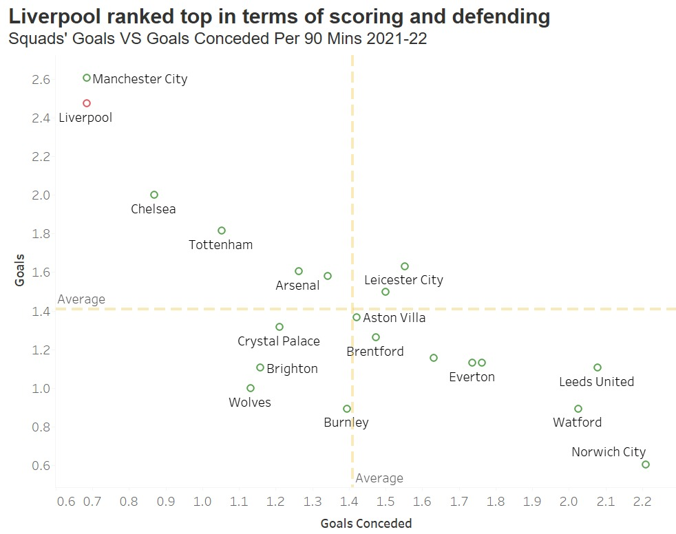

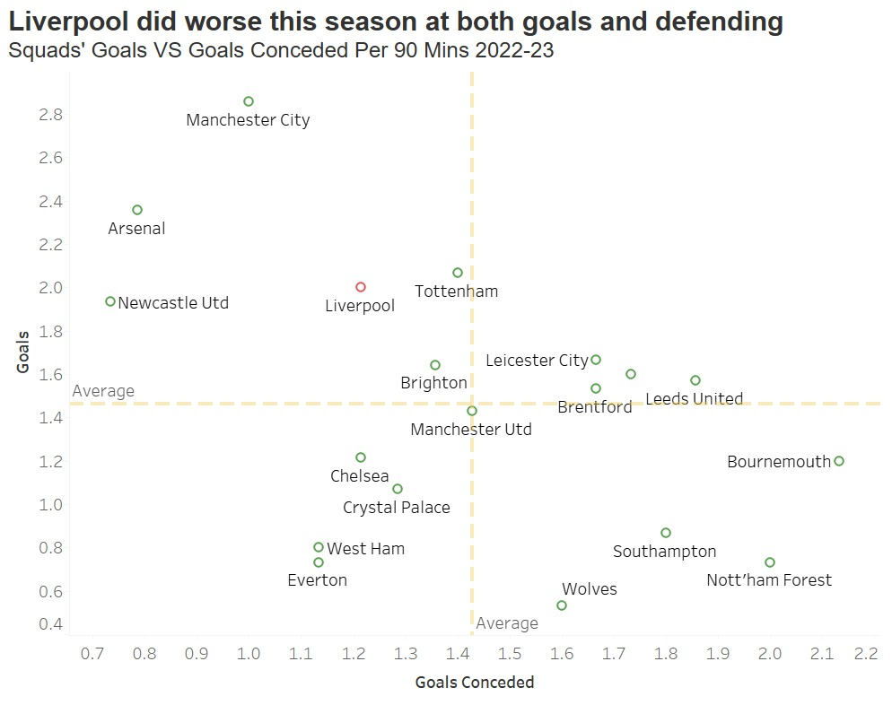

We are going to analyze the reason from player’s performance in different positions.

## Attacking

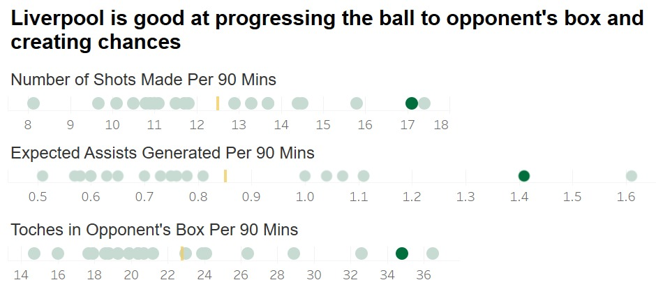

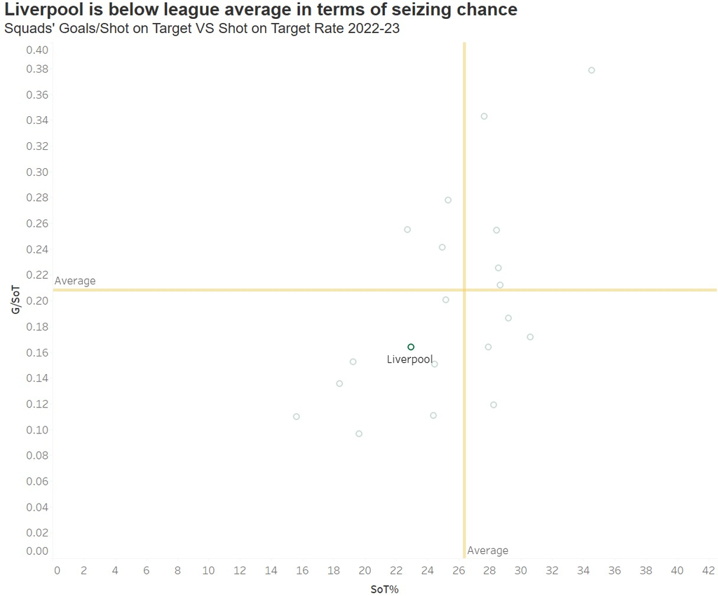

## Midfield

Midfield is critical for stopping opponent’s counter attack, especially for strong teams when facing weaker ones. In terms of press given, 3 main Liverpool midfield players are below the league average and did worse compared to last season. For tackles and intercept, still only Thiago is over league average and two of them did worse than last year.

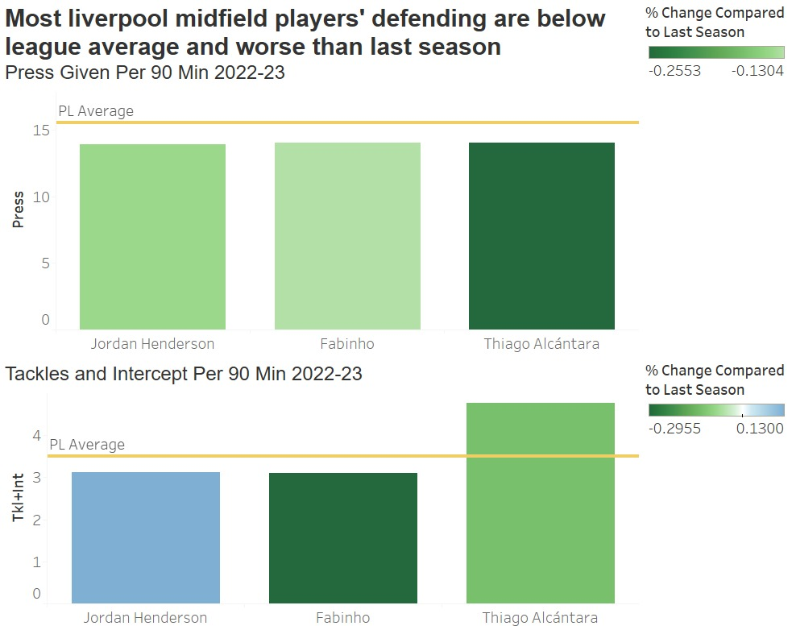

## Defender

Let’s look at one of the best center back in the league/the world, Virgil van Dijk’s defensive performance.

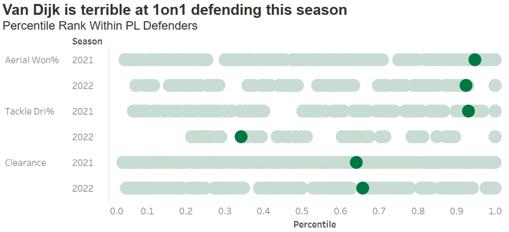

In terms of aerial won and clearance, Van dijk is still one of the best players. However, his 1 on 1 defending capacity lags behind this season, which is catastrophic if a center back can’t stop opponent players.

# Which role is each player playing?

On the pitch, different positions play different roles. FW are responsible for dribbling and shooting, (SoT,DriAtt,ScaDrib) MF are responsible of progress the ball and pass (ScaPassLive,PasProg,`PasTotCmp%`), DF take charge of defending (Clr, Blocks).

```r
# Filter out GK and choose essential stats
pos_radar <- players_22 %>%
  filter(Pos != "GK") %>%
  select(Player,Comp,Squad,Pos,
         SoT,DriAtt,ScaDrib,
         ScaPassLive,PasProg,Touches,`PasTotCmp%`,
         Press,`Tkl+Int`, Clr, Blocks,AerWon) %>%
  mutate(across(is.numeric, ~as.numeric(rescale(.,to = c(0,10)))))
# Calculate mean for each position
pos_mean<- pos_radar %>%
  group_by(Pos) %>%
  summarise(across(is.numeric,mean))
```

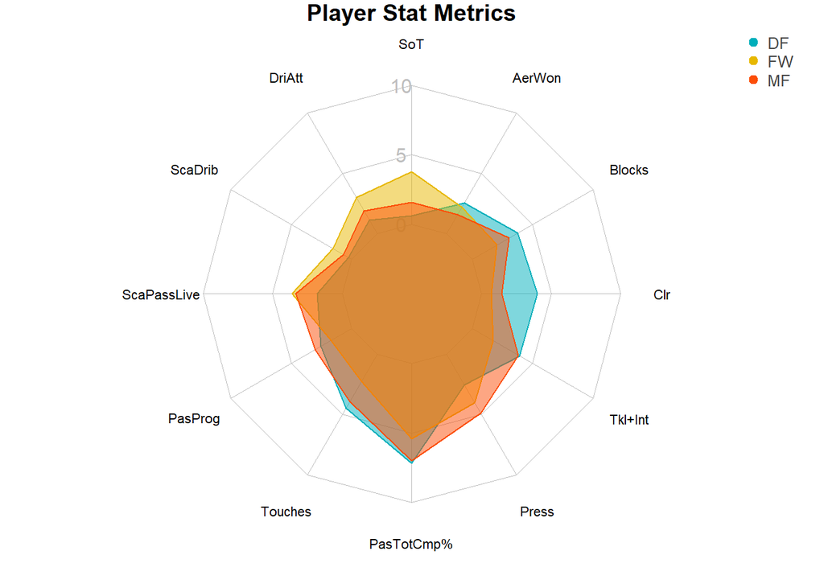

```r
color = c("#00AFBB", "#E7B800","#FC4E07")
# Maxinmum and minmum range
data <- rbind(rep(10,13), rep(0,13), pos_mean)

# Radar chart for each position
op <- par(mar = c(1,1,1,1))
create_beautiful_radarchart(
  data = data[,-1],caxislabels = c(0,5,10),
  color = color
)
legend("topright",
       legend = data$Pos[-c(1,2)],
       bty = "n", pch = 20, col = color,
       text.col = "grey25", pt.cex = 1.5,cex = 0.8)
title(main = "Player Stat Metrics")
```

```r
par(op)
```

However, even players of the same position, will have different roles. Arnold and Van Dijk are both DFs but Arnold clearly has more contribution to the attack.

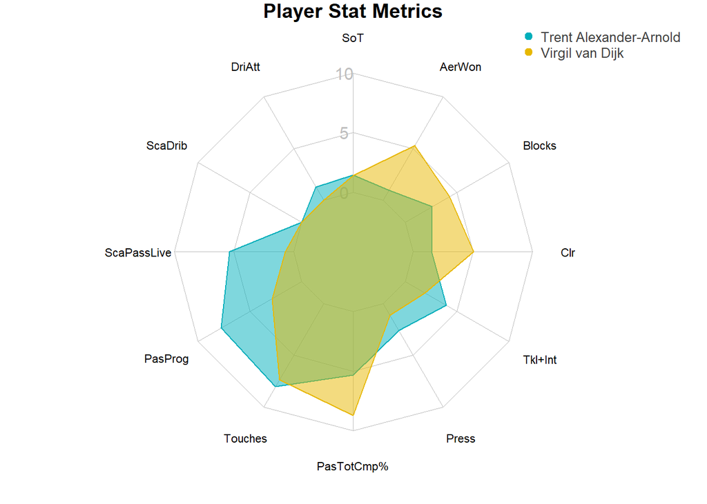

```r
# Comparison between chosen players
data<- pos_radar %>%
  filter(Player == "Trent Alexander-Arnold" | Player == "Virgil van Dijk") %>%
  select(-c(Comp,Squad,Pos))
color = c("#00AFBB", "#E7B800")
data <- rbind(rep(10,13), rep(0,13), data)

op <- par(mar = c(1,1,1,1))
create_beautiful_radarchart(
  data = data[,-1],caxislabels = c(0,5,10),
  color = color
)
legend("topright",
       legend = data$Player[-c(1,2)],
       bty = "n", pch = 20, col = color,
       text.col = "grey25", pt.cex = 1.5,cex = 0.8)
title(main = "Player Stat Metrics")
```

```r
par(op)
```

The reason is that Arnold is right back(RB) and Van Dijk is center back(CB). The truth is that MF can also be split into attack midfield(AM) and defend midfield(DM), FW has center forward(CF) and RW/LW(Wing). But our data doesn’t have this information, so we tried to use K-means clustering to see whether we can recognize those roles.

First we filter out Goalkeepers, and run a kmeans model using those stats with 3 clusters to clasify DF MF ans FW.

```r
pos_feature <- players_22 %>%
  filter(Pos != "GK") %>%
  select(Player,Comp,Squad,Pos,
         SoT,DriAtt,ScaDrib,
         ScaPassLive,PasProg,Touches,`PasTotCmp%`,
         Press,`Tkl+Int`, Clr, Blocks,AerWon)
```

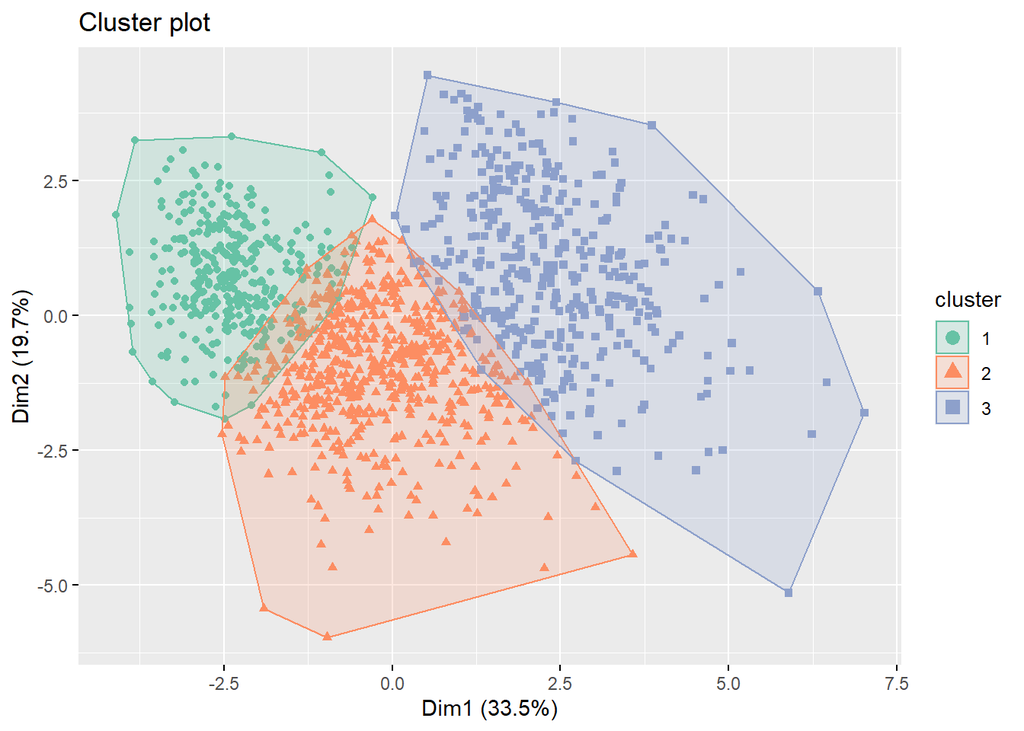

```r
set.seed(1234)
n = 3

selected_data <- pos_feature %>%
  select(-Player,-Comp,-Squad,-Pos)
#scale the data
selected_data<-data.frame(scale(selected_data))

#train kmeans clustering
kmeans<-eclust(selected_data, "kmeans", k = n,nstart = 50,graph= FALSE)

fviz_cluster(kmeans,selected_data, palette = "Set2",geom = "point")
```

The model can clearly split out 3 positions, with several points overlapping, which may be ambiguous positions such as wing back and defensive midfield.

Then we apply clustering within each position with k = 2, and identify the corresponding position by checking the cluster centers.

## DF

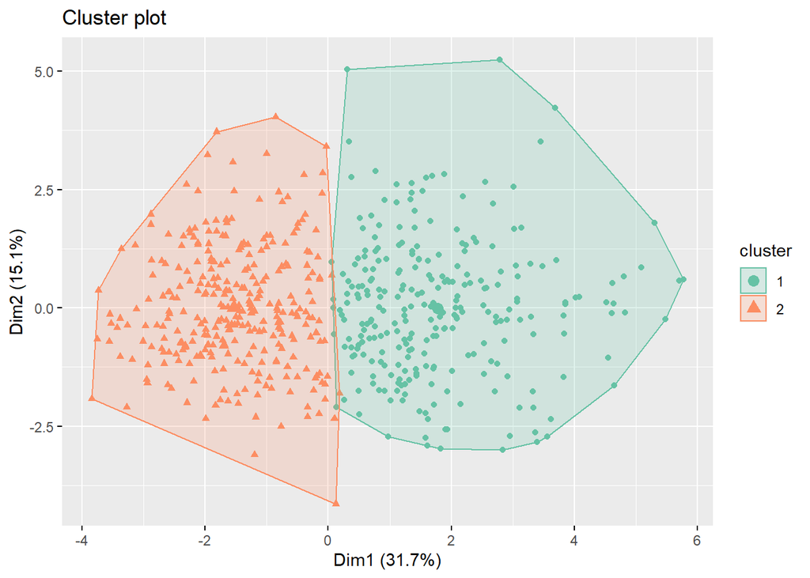

```r
fviz_cluster(kmeans,selected_data, palette = "Set2",geom = "point")
```

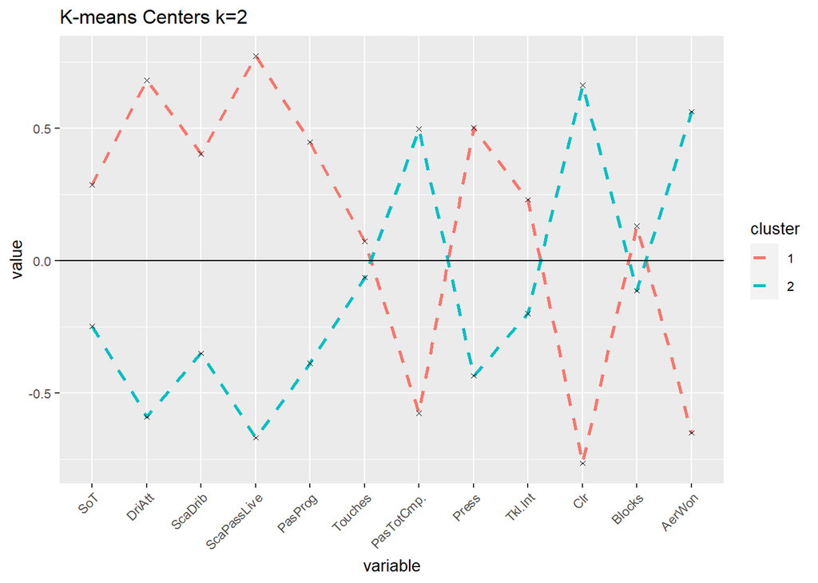

```r
#plot the centers
ggplot(cluster_centers_t, aes(x = variable, y = value))+
  geom_line(aes(color =cluster,group = cluster),
            linetype = "dashed",size=1)+
  geom_point(size=1,shape=4)+
  geom_hline(yintercept=0)+
  theme(text = element_text(size=10),
        axis.text.x = element_text(angle=45, hjust=1),)+
  ggtitle("K-means Centers k=2")
```

```r
pre_DF = pre_DF %>%
  mutate(cluster = case_when(cluster == 1 ~ "WB",
                             cluster == 2 ~ "CB"))
```

## MF

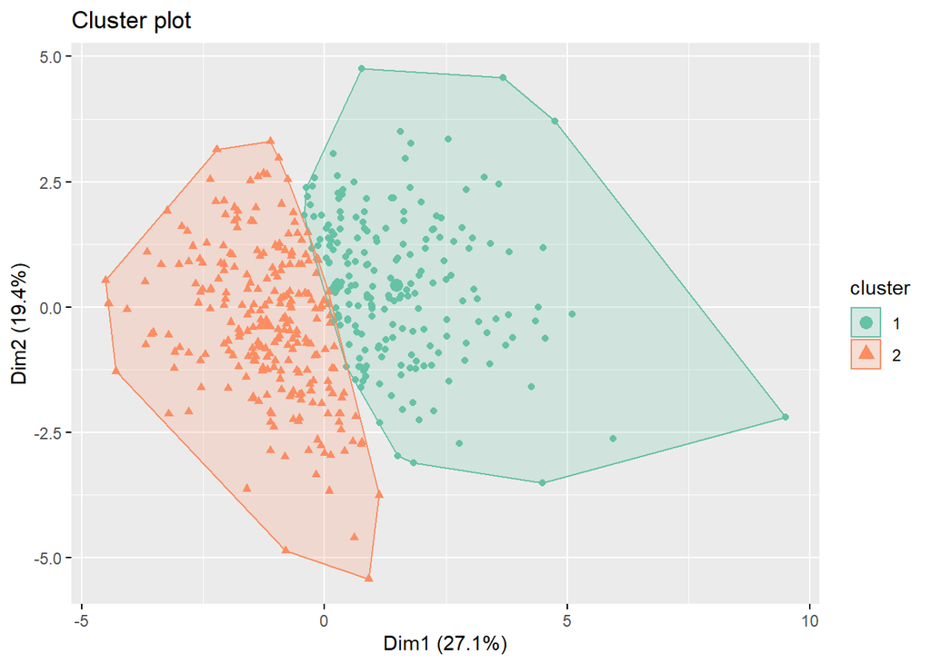

```r
fviz_cluster(kmeans,selected_data, palette = "Set2",geom = "point")
```

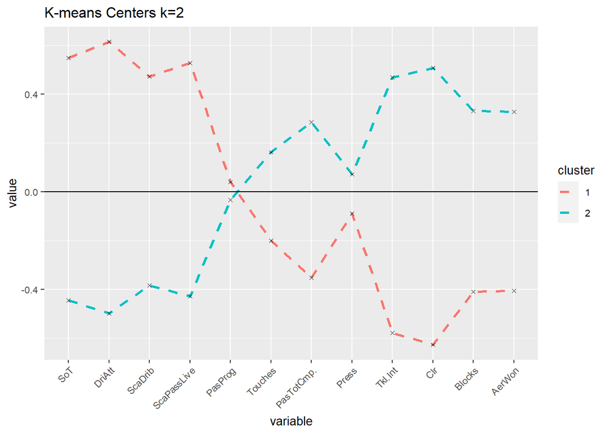

```r
#plot the centers
ggplot(cluster_centers_t, aes(x = variable, y = value))+
  geom_line(aes(color =cluster,group = cluster),
            linetype = "dashed",size=1)+
  geom_point(size=1,shape=4)+
  geom_hline(yintercept=0)+
  theme(text = element_text(size=10),
        axis.text.x = element_text(angle=45, hjust=1),)+
  ggtitle("K-means Centers k=2")
```

```r
pre_MF = pre_MF %>%
  mutate(cluster = case_when(cluster == 1 ~ "AM",
                             cluster == 2 ~ "DM"))
```

## FW

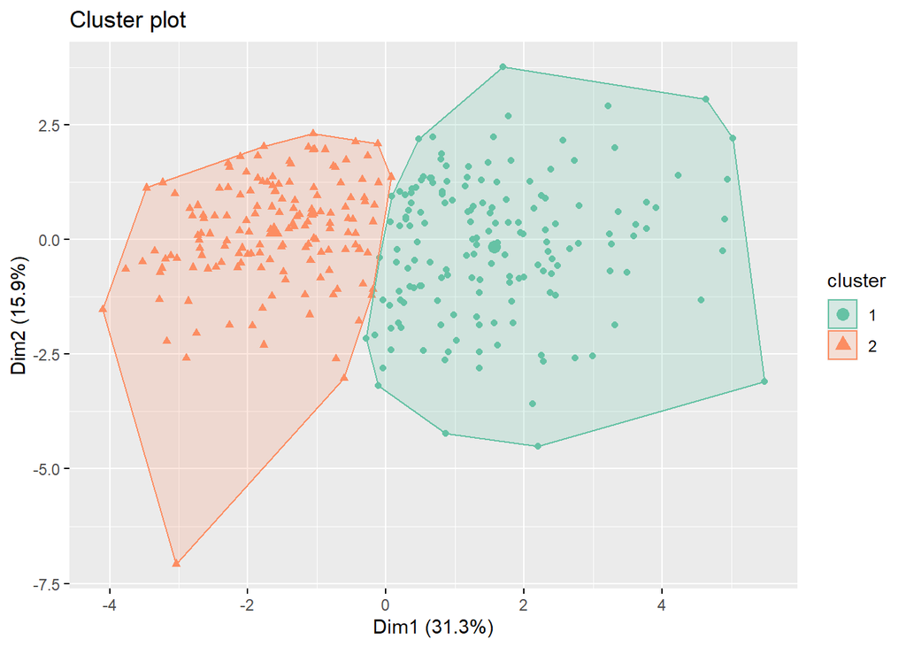

```r
fviz_cluster(kmeans,selected_data, palette = "Set2",geom = "point")
```

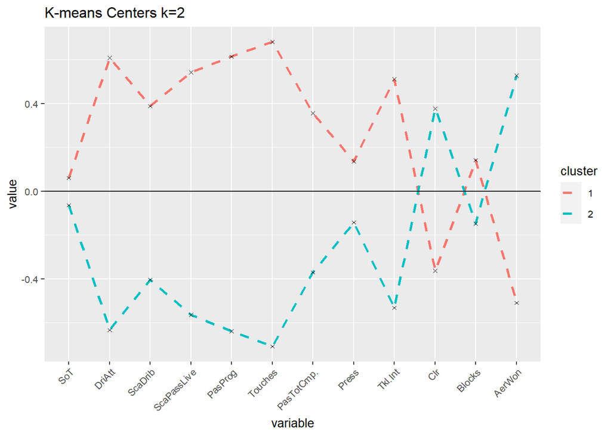

```r
#plot the centers
ggplot(cluster_centers_t, aes(x = variable, y = value))+
  geom_line(aes(color =cluster,group = cluster),
            linetype = "dashed",size=1)+
  geom_point(size=1,shape=4)+
  geom_hline(yintercept=0)+
  theme(text = element_text(size=10),
        axis.text.x = element_text(angle=45, hjust=1),)+
  ggtitle("K-means Centers k=2")
```

```r
pre_FW = pre_FW %>%
  mutate(cluster = case_when(cluster == 1 ~ "WF",
                             cluster == 2 ~ "CF"))
```

## Clustering Result

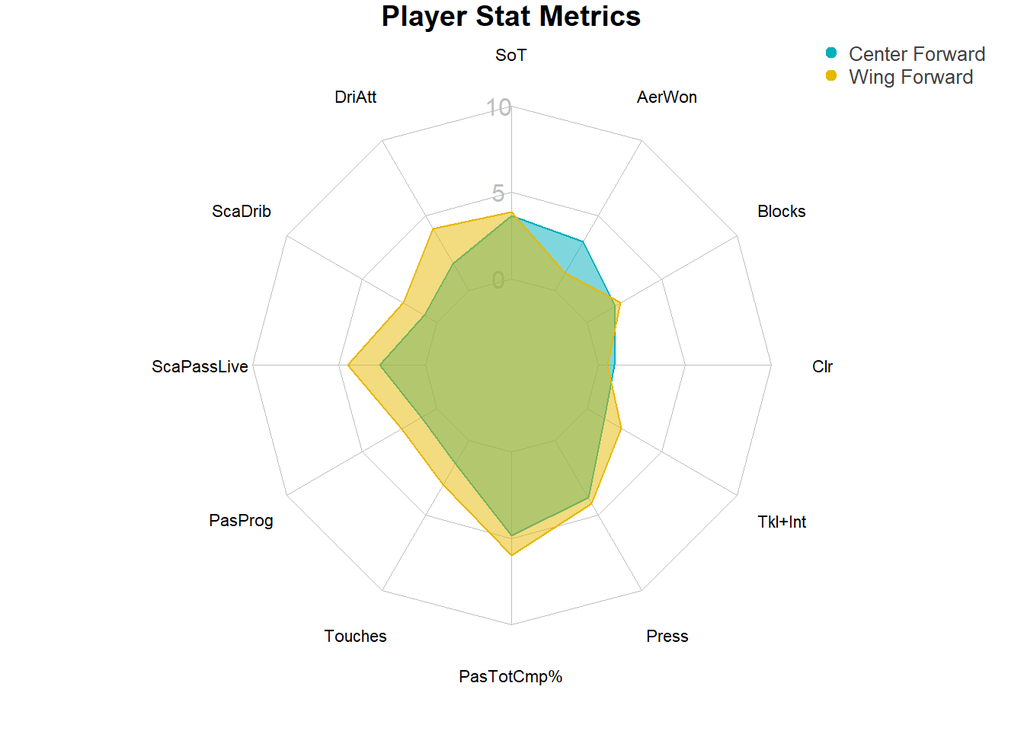

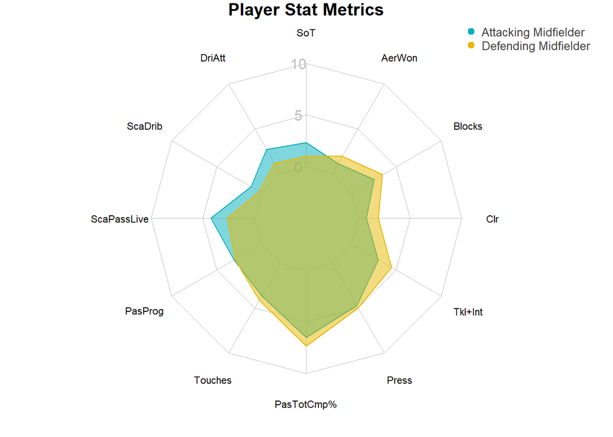

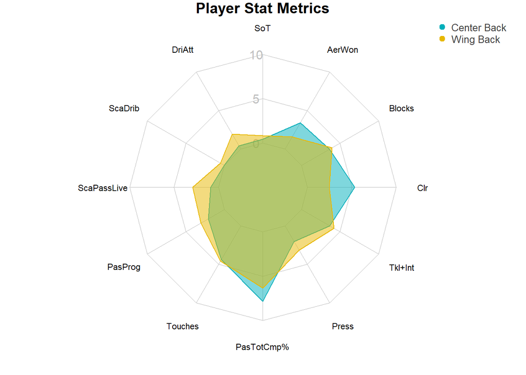

```r
# Radar chart between new positions
legend = c("Center Forward","Wing Forward",
           "Attacking Midfielder","Defending Midfielder",
           "Center Back", "Wing Back")

for(i in c(1,3,5)){
  data <- rbind(rep(10,13), rep(0,13), pos_mean[c(i,i+1),])
  op <- par(mar = c(1,1,1,1))
  create_beautiful_radarchart(
    data = data[,-1],caxislabels = c(0,5,10),
    color = color
  )
  legend("topright",
         legend = legend[c(i,i+1)],
         bty = "n", pch = 20, col = color,
         text.col = "grey25", pt.cex = 1.5,cex = 0.8)
  title(main = "Player Stat Metrics")
  par(op)
}
```

From the radar chart, we can compare each cluster’s strength, and is pretty close to our common knowledge about what each position are good at.

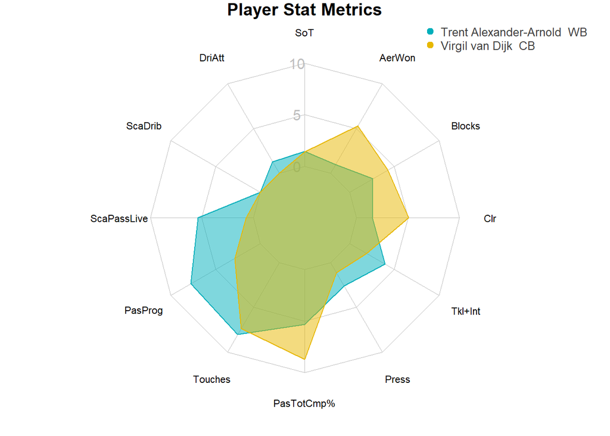

```r
# Comparison between chosen player
data<- pos_radar %>%
  filter(Player == "Trent Alexander-Arnold" | Player == "Virgil van Dijk") %>%
  mutate(name_pos = paste(Player,"",cluster)) %>%
  select(-c(Comp,Squad,cluster,Player))
color = c("#00AFBB", "#E7B800")
data <- rbind(rep(10,13), rep(0,13), data)

op <- par(mar = c(1,1,1,1))
create_beautiful_radarchart(
  data = data[,-13],caxislabels = c(0,5,10),
  color = color
)
legend("topright",
       legend = data$name_pos[-c(1,2)],
       bty = "n", pch = 20, col = color,
       text.col = "grey25", pt.cex = 1.5,cex = 0.8)
title(main = "Player Stat Metrics")
```

```r
par(op)
```

We can also compare Arnold and Van Dijk again and now they are classified into different positions now.

# Conclusion

We have identified the problem Liverpool is facing this season: Poor conversion rate, dropping midfielder and center back’s defending performance. And we are going to recommend players for Liverpool in each position (Not from their competitors).

## Forward

Clearly they need a player with higher conversion rate.

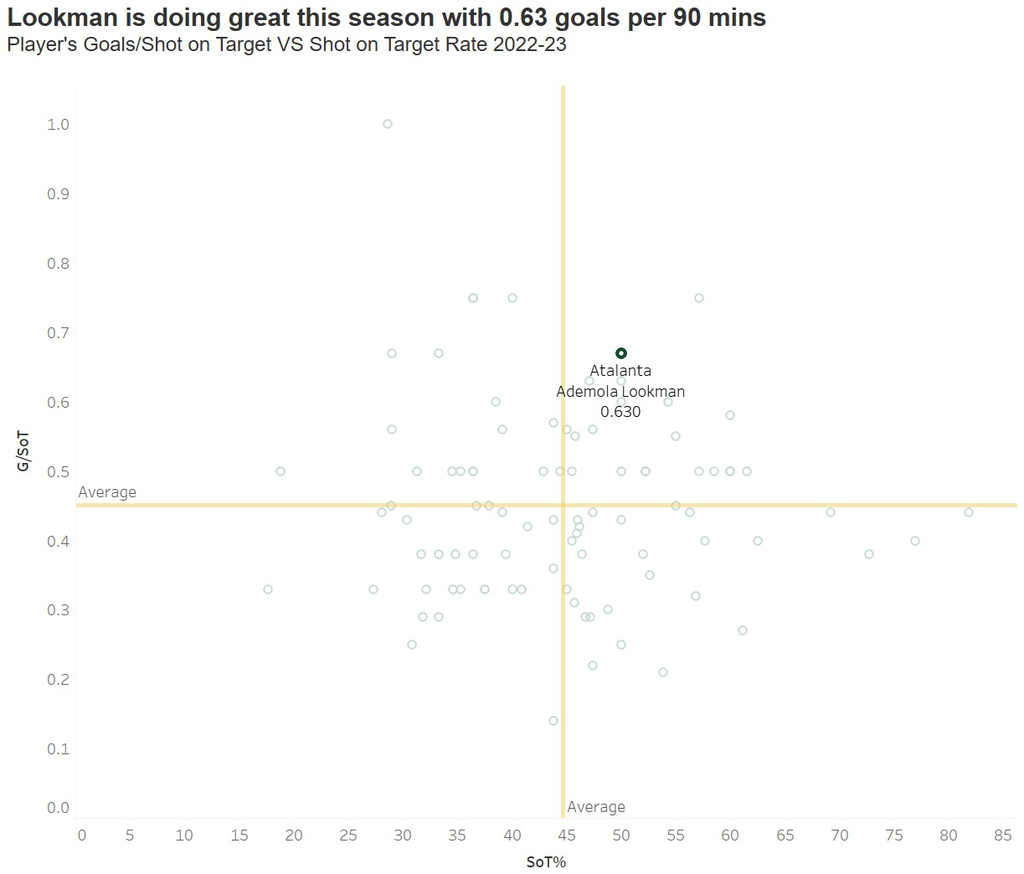

## Defensive Midfield

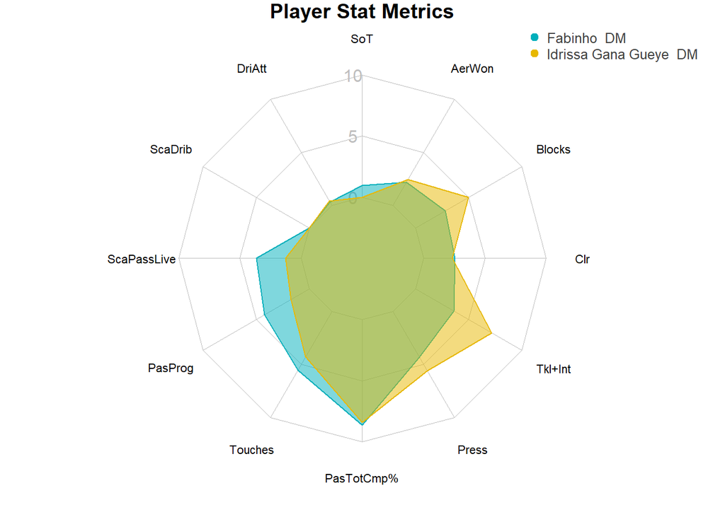

```r
data<- pos_radar %>%
  filter(Player == "Fabinho" | Player == "Idrissa Gana Gueye") %>%
  mutate(name_pos = paste(Player,"",cluster)) %>%
  select(-c(Comp,Squad,cluster,Player))
color = c("#00AFBB", "#E7B800")
data <- rbind(rep(10,13), rep(0,13), data)

op <- par(mar = c(1,1,1,1))
create_beautiful_radarchart(
  data = data[,-13],caxislabels = c(0,5,10),
  color = color
)
legend("topright",
       legend = data$name_pos[-c(1,2)],
       bty = "n", pch = 20, col = color,
       text.col = "grey25", pt.cex = 1.5,cex = 0.8)
title(main = "Player Stat Metrics")
```

```r
par(op)
```

## Center Back

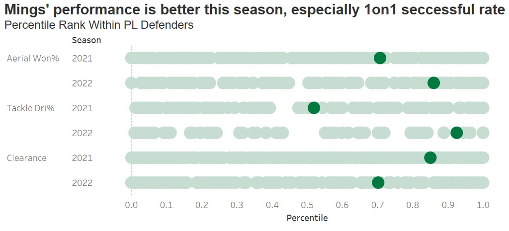